# Bootcamp: Analista de Banco de Dados - Desafion do Módulo 03

[figure not shown]

### Enunciado

- **A partir de dados da Força Aérea Brasileira sobre a aviação civil Brasileira (CENIPA - Ocorrências Aeronáuticas na Aviação Civil),vamos importar algumas informações no MongoDB para executar análises.**
- **Arquivos com os quais trabalharemos:**
  - **Ocorrencia.csv - Informações sobre as ocorrências.**
  - **Ocorrencia_tipo.csv - Informações sobre o tipo de ocorrência.**
  - **Aeronave.csv - Informações sobre as aeronaves envolvidas nas ocorrências.**
- **Alguns ajustes foram executados para facilitar nosso estudo, tais como eliminação de caracteres especiais, acentos e ajustes nos campos data e hora para facilitar a importação no MongoDB.**

*Fonte: [dados abertos](https://dados.gov.br/dados/conjuntos-dados/ocorrencias-aeronauticas-da-aviacao-civil-brasileira)*

- **A base de dados de ocorrências aeronáuticas é gerenciada pelo Centro de Investigação e Prevenção de Acidentes Aeronáuticos (CENIPA). Constam nesta base de dados as ocorrências aeronáuticas notificadas ao CENIPA nos últimos 10 anos que ocorreram em solo brasileiro.** **Dentre as informações disponíveis estão os dados sobre as aeronaves envolvidas, fatalidades, local, data, horário dos eventos e informações taxonômicas típicas das investigações de acidentes (AIG).**

**Importando a biblioteca pymongo**.

- caso não possua a lib pode ser instalada usando !pip install pymongo

```python
# import das libs
import pymongo
```

**Conectando ao mongoDB, nesse exemplo estamos usando a conexão local padrão sem usuário/senha**.

```python
# Conectar ao servidor do MongoDB
client = pymongo.MongoClient('localhost', 27017)
```

**Criando uma banco de dados chamado “desafio”.**

```python
db = client['desafio']
```

**Imprimindo a conexão com o db recém criado**

```python
print(db)
```

```
Database(MongoClient(host=['localhost:27017'], document_class=dict, tz_aware=False, connect=True), 'desafio')
```

**Criando a collection “ocorrencia” com validador.**

```python
db = client["desafio"]
ocorrencia_collection = db.create_collection("ocorrencia", validator={
    "$jsonSchema": {
        "bsonType": "object",
        "properties": {
            "id_ocorrencia": {
                "bsonType": "int",
                "description": "ID da ocorrência"
            },
            "classificacao": {
                "bsonType": "string",
                "description": "is not required"
            },
            "cidade": {
                "bsonType": "string",
                "description": "is not required"
            },
            "uf": {
                "bsonType": "string",
                "description": "is not required"
            },
            "pais": {
                "bsonType": "string",
                "description": "is not required"
            },
            "data": {
                "bsonType": "date",
                "description": "is not required"
            },
            "num_recomendacoes": {
                "bsonType": "int",
                "description": "is not required"
            }
        }
    }
})

# verifica se a collection foi criada com o validator
collection_info = db.get_collection("ocorrencia").options()
if "validator" in collection_info:
    print("A collection 'ocorrencia' foi criada com o validator.")
else:
    print("A collection 'ocorrencia' não foi criada com o validator.")
```

```
A collection 'ocorrencia' foi criada com o validator.
```

- **O validator é definido como um dicionário JSON, que define as regras para os campos que serão inseridos na coleção. Neste caso, são definidos os tipos de dados e as propriedades obrigatórias para cada campo.**

**Criando a collection “ocorrencia_tipo” com validador.**

```python
# Seleciona o database e cria a collection ocorrencia_tipo com validator
db = client.desafio
db.create_collection('ocorrencia_tipo', validator={
    '$jsonSchema': {
        'bsonType': 'object',
        'properties': {
            'id_ocorrencia_t': {
                'bsonType': 'int',
                'description': 'is not required'
            },
            'tipo': {
                'bsonType': 'string',
                'description': 'is not required'
            }
        }
    }
})

# verifica se a collection foi criada com o validator
collection_info = db.get_collection("ocorrencia_tipo").options()
if "validator" in collection_info:
    print("A collection 'ocorrencia_tipo' foi criada com o validator.")
else:
    print("A collection 'ocorrencia_tipo' não foi criada com o validator.")
```

```
A collection 'ocorrencia_tipo' foi criada com o validator.
```

**Criando a collection “aeronave” com validador.**

```python
# Seleciona o database e cria a collection aeronave com validator
db = client["desafio"]
aeronave_collection = db["aeronave"] # var para armazenar o nome da collection a ser criada

# var para armazenar as configurações do validator
aeronave_validator = {
    "$jsonSchema": {
        "bsonType": "object",
        "required": ["assentos", "ano_fabricacao"],
        "properties": {
            "id_ocorrencia_a": {
                "bsonType": "int",
                "description": "is not required"
            },
            "matricula": {
                "bsonType": "string",
                "description": "is not required"
            },
            "operador_categoria": {
                "bsonType": "string"
            },
            "tipo_veiculo": {
                "bsonType": "string",
                "description": "is not required"
            },
            "fabricante": {
                "bsonType": "string",
                "description": "is not required"
            },
            "modelo": {
                "bsonType": "string",
                "description": "is not required"
            },
            "motor_tipo": {
                "bsonType": "string"
            },
            "motor_quantidade": {
                "bsonType": "string"
            },
            "assentos": {
                "bsonType": "int",
                "minimum": 1,
                "maximum": 1000,
                "description": "must be an integer in [1, 1000] and is required"
            },
            "ano_fabricacao": {
                "bsonType": "int",
                "minimum": 1950,
                "maximum": 2030,
                "description": "must be an integer in [1950, 2030] and is required"
            },
            "pais_fabricante": {
                "bsonType": "string"
            },
            "registro_segmento": {
                "bsonType": "string"
            },
            "voo_origem": {
                "bsonType": "string"
            },
            "voo_destino": {
                "bsonType": "string"
            },
            "fase_operacao": {
                "bsonType": "string"
            }
        }
    }
}

aeronave_collection.drop() # remove a collection se já existir

aeronave_collection = db.create_collection("aeronave", validator=aeronave_validator) # cria a collection com o validator.


# verifica se a collection foi criada com o validator
collection_info = db.get_collection("aeronave").options()
if "validator" in collection_info:
    print("A collection 'aeronave' foi criada com o validator.")
else:
    print("A collection 'aeronave' não foi criada com o validator.")
```

```
A collection 'aeronave' foi criada com o validator.
```

**Carregando documentos na collection “aeronave” através de um arquivo.csv usando Pandas.**

```python
import pandas as pd

# Selecionar o banco de dados
db = client['desafio']

# Selecionar a coleção
collection = db['aeronave']

# Limpar a coleção antes de importar
# collection.remove({})

# Ler o arquivo CSV com o pandas
df = pd.read_csv('./aeronave.csv', delimiter=';',encoding="iso-8859-1") # necessário usar o encoding pois estava com erro.

# Converter o DataFrame para uma lista de dicionários
data = df.to_dict('records')

# Inserir os documentos na coleção
collection.insert_many(data)
```

BulkWriteError: batch op errors occurred, full error: {'writeErrors': [{'index': 97, 'code': 121, 'errmsg': 'Document failed validation', 'errInfo': {'failingDocumentId': ObjectId('63f94d0617a43afe40cc737a'), 'details': {'operatorName': '$jsonSchema', 'schemaRulesNotSatisfied': [{'operatorName': 'properties', 'propertiesNotSatisfied': [{'propertyName': 'ano_fabricacao', 'description': 'must be an integer in [1950, 2030] and is required', 'details': [{'operatorName': 'minimum', 'specifiedAs': {'minimum': 1950}, 'reason': 'comparison failed', 'consideredValue': 1946}]}]}]}}, 'op': {'id_ocorrencia_a': 40271, 'matricula': 'PPRTO', 'operador_categoria': '***', 'tipo_veiculo': 'AVIAO', 'fabricante': 'CIA AERONAUTICA PAULISTA', 'modelo': 'CAP-4', 'motor_tipo': 'PISTAO', 'motor_quantidade': 'MONOMOTOR', 'assentos': 2, 'ano_fabricacao': 1946, 'pais_fabricante': 'BRASIL', 'registro_segmento': 'INSTRUCAO', 'voo_origem': 'ENCANTA MOCA', 'voo_destino': 'FAZENDA BUSATO 1', 'fase_operacao': 'DECOLAGEM', '_id': ObjectId('63f94d0617a43afe40cc737a')}}], 'writeConcernErrors': [], 'nInserted': 97, 'nUpserted': 0, 'nMatched': 0, 'nModified': 0, 'nRemoved': 0, 'upserted': []}

- **Se observarmos o erro, podemos entender que nosso validator foi criado com restrição para 'ano_fabricação com minimo:1950 e foram encontrados valores abaixo disso como 1946.**
- **O erro foi proposital, para verificarmos na pratica as restrições impostas pelo validador.**
- **Após corrigir esse erro, conforme o enunciado já sabemos que existe um outro erro com assentos menor do que o mínimo imposto, para poupar o retrabalho vamos realizar as devidas correções, visto que já foi possível entender o propósito.**

**Para solução desse erro vamos alterar "ano_fabricação" mínimo para 1900 e "assentos" mínimo para 0, assim conseguimos importar todos os documentos do arquivo aeronave.csv**.

```python
# Realizando as alterações na collection aeronave.
# Seleciona o database "Desafio"
db = client["desafio"]

# Define a nova validação para a collection "aeronave"
validator = {
    "$jsonSchema": {
        "bsonType": "object",
        "required": ["assentos", "ano_fabricacao"],
        "properties": {
            "id_ocorrencia_a": {
                "bsonType": "int",
                "description": "is not required"
            },
            "matricula": {
                "bsonType": "string",
                "description": "is not required"
            },
            "operador_categoria": {
                "bsonType": "string"
            },
            "tipo_veiculo": {
                "bsonType": "string",
                "description": "is not required"
            },
            "fabricante": {
                "bsonType": "string",
                "description": "is not required"
            },
            "modelo": {
                "bsonType": "string",
                "description": "is not required"
            },
            "motor_tipo": {
                "bsonType": "string"
            },
            "motor_quantidade": {
                "bsonType": "string"
            },
            "assentos": {
                "bsonType": "int",
                "minimum": 0,
                "maximum": 1000,
                "description": "must be an integer in [ 0, 1000 ] and is required"
            },
            "ano_fabricacao": {
                "bsonType": "int",
                "minimum": 1900,
                "maximum": 2030,
                "description": "must be an integer in [ 1900, 2030 ] and is required"
            },
            "pais_fabricante": {
                "bsonType": "string"
            },
            "registro_segmento": {
                "bsonType": "string"
            },
            "voo_origem": {
                "bsonType": "string"
            },
            "voo_destino": {
                "bsonType": "string"
            },
            "fase_operacao": {
                "bsonType": "string"
            }
        }
    }
}

# Executa o comando "collMod" para atualizar a validação da collection "aeronave"
db.command({"collMod": "aeronave", "validator": validator})
```

```
{'ok': 1.0}
```

```python
# Quantidade de registro inclusos no arquivo csv.
df.count()[0]
```

```
5303
```

**Agora vamos realizar a carga novamente**

```python
# Selecionar o banco de dados
db = client['desafio']

# Selecionar a coleção
collection = db['aeronave']

# Limpar a coleção antes de importar para evitar erros
collection.delete_many({})

# Ler o arquivo CSV com o pandas
df = pd.read_csv('./aeronave.csv', delimiter=';',encoding="iso-8859-1")

# Converter o DataFrame para uma lista de dicionários
data = df.to_dict('records')

# Inserir os documentos na coleção
collection.insert_many(data)

# Verifique o número de documentos na coleção
num_docs = db.aeronave.count_documents({})
expected_num_docs = 5303  # número de documentos esperados no arquivo csv já verificado

if num_docs == expected_num_docs:
    print("O arquivo foi carregado com sucesso!")
    print('='*50)
    print(f'Total de documentos:{num_docs}')
    print('='*50)
else:
    print("Ocorreu um erro durante o carregamento do arquivo.")
```

```
O arquivo foi carregado com sucesso!
==================================================
Total de documentos:5303
==================================================
```

**Carregando os documentos na collection “ocorrencia_tipo” através de um arquivo.csv.**

```python
# Selecionar o banco de dados
db = client['desafio']

# Selecionar a coleção
collection = db['ocorrencia_tipo']

# Limpar a coleção antes de importar para evitar erros
collection.delete_many({})

# Ler o arquivo CSV com o pandas
df = pd.read_csv('./ocorrencia_tipo.csv', delimiter=';',encoding="iso-8859-1")

# Converter o DataFrame para uma lista de dicionários
data = df.to_dict('records')

# Inserir os documentos na coleção
collection.insert_many(data)

# Verifique o número de documentos na coleção
num_docs = db.ocorrencia_tipo.count_documents({})
expected_num_docs = df.count()[0]  # número de documentos esperados no arquivo csv

if num_docs == expected_num_docs:
    print("O arquivo foi carregado com sucesso!")
    print('='*50)
    print(f'Total de documentos:{num_docs}')
    print('='*50)
else:
    print("Ocorreu um erro durante o carregamento do arquivo.")
```

```
O arquivo foi carregado com sucesso!
==================================================
Total de documentos:5337
==================================================
```

**Carregando documentos na collection “ocorrencia”.**

```python
# necessário a intalação para conveter 'data' para o tipo date
#!pip install iso8601
```

```python
from iso8601 import parse_date # import for !pip install iso8601 pois o pandas não conseguiu converter sozinho.

#função para converter o atributo 'data' para o tipo date.
def my_date_parser(date_string):
    return parse_date(date_string)

# Selecionar o banco de dados
db = client['desafio']

# Selecionar a coleção
collection = db['ocorrencia']

# Limpar a coleção antes de importar para evitar erros
collection.delete_many({})

# Ler o arquivo CSV com o pandas
df = pd.read_csv('./ocorrencia.csv', delimiter=';', parse_dates=['data'], date_parser=my_date_parser, encoding="iso-8859-1") # resolvendo o problema do tipo date

# Converter o DataFrame para uma lista de dicionários
data = df.to_dict('records')

# Inserir os documentos na coleção
collection.insert_many(data)

# Verifique o número de documentos na coleção
num_docs = db.ocorrencia.count_documents({})
expected_num_docs = df.count()[0]  # número de documentos esperados no arquivo csv

if num_docs == expected_num_docs:
    print("O arquivo foi carregado com sucesso!")
    print('='*50)
    print(f'Total de documentos:{num_docs}')
    print('='*50)
else:
    print("Ocorreu um erro durante o carregamento do arquivo.")
```

```
O arquivo foi carregado com sucesso!
==================================================
Total de documentos:5242
==================================================
```

- **Com isso termimanos a parte Criação e Carregamento dos documentos.**
- **Agora podemos realizar algumas consultas e responder algumas perguntas.**

**1-Qual é o tipo de ocorrência mais comum na aviação civil brasileira?**

```python
# Executar a consulta utilizando aggregate()
ocorrencias_tipo = db.ocorrencia_tipo.aggregate([
    {
        '$group': {
            '_id': '$tipo',
            'count': {'$sum': 1}
        }
    },
    {
        '$sort': {'count': -1}
    },
    {
        '$limit': 1
    }
])

# Exibir o resultado
for tipo in ocorrencias_tipo:
    print(f"O tipo de ocorrência mais comum é '{tipo['_id']}' com um total de {tipo['count']} ocorrências.")
```

```
O tipo de ocorrência mais comum é 'FALHA DO MOTOR EM VOO' com um total de 637 ocorrências.
```

**2-Qual é a distribuição de ocorrências ao longo dos anos? Existe algum ano com mais ocorrências?**

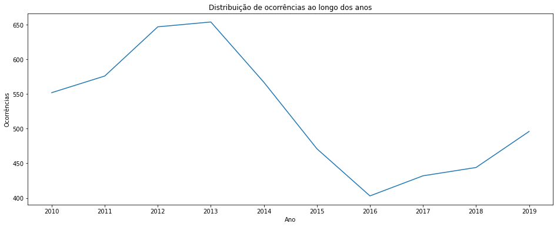

```python
import matplotlib.pyplot as plt

ocorrencia = db['ocorrencia']

# Agrupando as ocorrências por ano
pipeline = [
    {"$group": {
        "_id": {
            "ano": {"$year": "$data"}
        },
        "total": {"$sum": 1}
    }},
    {"$sort": {"_id": 1}}
]
result = ocorrencia.aggregate(pipeline)

# Plotando o gráfico de distribuição
anos = []
ocorrencias = []
for r in result:
    ano = str(r['_id']['ano'])
    total = r['total']
    anos.append(ano)
    ocorrencias.append(total)

plt.figure(figsize=(16,6))
plt.plot(anos, ocorrencias)
plt.xlabel('Ano')
plt.ylabel('Ocorrências')
plt.title('Distribuição de ocorrências ao longo dos anos')
plt.show()
```

- **2012 e 2013 foram os anos de maior ocorrências**.
- **2016 foi o ano que houveram a menor quantidade de ocorrência no período dos 10 anos**.

**3-Quais são as aeronaves mais envolvidas em ocorrências? Existe algum modelo de aeronave com maior incidência de ocorrências?**

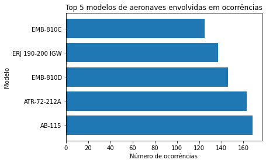

```python
aeronave_col = db['aeronave']

# Agregação para contar as ocorrências por fabricante de aeronave
pipeline = [
    {"$group": {"_id": "$modelo", "count": {"$sum": 1}}},
    {"$sort": {"count": -1}},
    {"$limit": 5}
]
result = list(aeronave_col.aggregate(pipeline))

# Lista com os modelos de aeronaves e número de ocorrências
labels = [doc['_id'] for doc in result]
values = [doc['count'] for doc in result]

# Plotando o gráfico de barras
plt.barh(labels, values)
plt.title("Top 5 modelos de aeronaves envolvidas em ocorrências")
plt.xlabel("Número de ocorrências")
plt.ylabel("Modelo")
plt.show()
```

- **Os modelos "AB-115" e "ATR-72-212A" foram os que tiveram maior número de ocorrências.**

**4-Qual é a proporção de ocorrências com classificação: 'Incidente grave' em relação ao total de ocorrências?**

```python
# contagem total de ocorrências
total_ocorrencias = db.ocorrencia.count_documents({})

# contagem de ocorrências com classificação igual a 'INCIDENTE GRAVE'
ocorrencias_graves = db.ocorrencia.count_documents({'classificacao': 'INCIDENTE GRAVE'})

# proporção de ocorrências graves em relação ao total de ocorrências
proporcao = ocorrencias_graves / total_ocorrencias

print(f"A proporção de ocorrências graves é de {round(proporcao*100, 2)}%.")
```

```
A proporção de ocorrências graves é de 12.59%.
```

**5-Verifique se todas as aeronaves possuem correspondência com a collection ocorrencia, pois existem mais documentos na collection aeronave do que na collection ocorrencia.**

```python
# verificando se existem aeronaves sem correspondência na collection ocorrencia
pipeline = [
    {
        "$lookup": {
            "from": "ocorrencia",
            "localField": "id_ocorrencia_a",
            "foreignField": "id_ocorrencia",
            "as": "ocorrencia"
        }
    },
    {
        "$match": {
            "ocorrencia": {"$size": 0}
        }
    }
]

result = list(db.aeronave.aggregate(pipeline))

if len(result) > 0:
    print("Existem aeronaves sem correspondência na collection ocorrencia:")
    for doc in result:
        print(doc)
else:
    print("Todas as aeronaves possuem correspondência na collection ocorrencia.")
```

```
Todas as aeronaves possuem correspondência na collection ocorrencia.
```

- **Bom já que todas as aeronaves possuem ocorrências, possívelmente temos aeronaves com mais de 1 ocorrência, armazene o id_ocorrencia_a dessas aeronaves em uma lista**.

```python
# Fazer a agregação
pipeline = [
    {
        '$group': {
            '_id':'$id_ocorrencia_a',
            'count': {'$sum': 1}
        }
    },

    {
        '$match': {
            'count': {'$gt': 1}
        }
    },
    {
        '$sort': {
            'count': -1
        }
    }
]

result = db.aeronave.aggregate(pipeline)

# Imprimir os resultados
lista_aeronave_com_ocorr_rep = []
for doc in result:
    lista_aeronave_com_ocorr_rep.append(doc['_id']) # armazena os ids repetidos
    #print(doc['_id'], doc['count']) #imprime o id e a quantidade de repetições
```

- **Use a lista para filtrar as 3 collections, assim podemos saber quais as aeronaves, tipos e ocorrencia correspondentes**.

```python
# Ids das ocorrências a serem filtradas
ids_ocorrencia = lista_aeronave_com_ocorr_rep

# Operação de agregação
pipeline = [
    # Filtro pelas ocorrências desejadas
    { '$match': { 'id_ocorrencia': { '$in': ids_ocorrencia } } },
    # Junção com a collection ocorrencia_tipo
    { '$lookup': {
        'from': 'ocorrencia_tipo',
        'localField': 'id_ocorrencia',
        'foreignField': 'id_ocorrencia_t',
        'as': 'tipo_ocorrencia'
    } },
    # Unwind para separar os documentos dos tipos de ocorrência
    { '$unwind': '$tipo_ocorrencia' },
    # Junção com a collection aeronave
    { '$lookup': {
        'from': 'aeronave',
        'localField': 'id_ocorrencia',
        'foreignField': 'id_ocorrencia_a',
        'as': 'aeronave'
    } },
    # Unwind para separar os documentos das aeronaves
    { '$unwind': '$aeronave' },
    # Seleção dos campos desejados
    { '$project': {
        '_id': 0,
        'id_ocorrencia': 1,
        'classificacao': 1,
        'cidade': 1,
        'uf': 1,
        'tipo_ocorrencia.tipo': 1,
        'aeronave.tipo_veiculo': 1,
        'aeronave.fabricante': 1,
        'aeronave.modelo': 1
    } }
]

result = db.ocorrencia.aggregate(pipeline)

# iteração pelo resultado e impressão dos documentos
for doc in result:
    print('ocorrencia:',{'id_ocorrencia':doc['id_ocorrencia'],'classificação':doc['classificacao'],'cidade':doc['cidade'],'uf':doc['uf']})
    print('dados_tipo:', doc['tipo_ocorrencia'])
    print('dados_aeronave:', doc['aeronave'])
    print('-'*100)
```

```
ocorrencia: {'id_ocorrencia': 41609, 'classificação': 'INCIDENTE', 'cidade': 'ARACAJU', 'uf': 'SE'}
dados_tipo: {'tipo': 'COLISAO COM AERONAVE NO SOLO'}
dados_aeronave: {'tipo_veiculo': 'AVIAO', 'fabricante': 'BOEING COMPANY', 'modelo': '737-85F'}
----------------------------------------------------------------------------------------------------
ocorrencia: {'id_ocorrencia': 41609, 'classificação': 'INCIDENTE', 'cidade': 'ARACAJU', 'uf': 'SE'}
dados_tipo: {'tipo': 'COLISAO COM AERONAVE NO SOLO'}
dados_aeronave: {'tipo_veiculo': 'AVIAO', 'fabricante': 'AIRBUS INDUSTRIE', 'modelo': 'A319-132'}
----------------------------------------------------------------------------------------------------
ocorrencia: {'id_ocorrencia': 43869, 'classificação': 'ACIDENTE', 'cidade': 'RIO DE JANEIRO', 'uf': 'RJ'}
dados_tipo: {'tipo': 'COLISAO DE AERONAVES EM VOO'}
dados_aeronave: {'tipo_veiculo': 'ULTRALEVE', 'fabricante': 'FABRICACAO PROPRIA', 'modelo': 'FOX V5 SUPER'}
----------------------------------------------------------------------------------------------------
ocorrencia: {'id_ocorrencia': 43869, 'classificação': 'ACIDENTE', 'cidade': 'RIO DE JANEIRO', 'uf': 'RJ'}
dados_tipo: {'tipo': 'COLISAO DE AERONAVES EM VOO'}
dados_aeronave: {'tipo_veiculo': 'ULTRALEVE', 'fabricante': '***', 'modelo': 'FOX II'}
----------------------------------------------------------------------------------------------------
ocorrencia: {'id_ocorrencia': 44944, 'classificação': 'ACIDENTE', 'cidade': 'CORUMBA', 'uf': 'MS'}
dados_tipo: {'tipo': 'COLISAO DE AERONAVES EM VOO'}
dados_aeronave: {'tipo_veiculo': 'AVIAO', 'fabricante': '***', 'modelo': 'N-592-420'}
----------------------------------------------------------------------------------------------------
ocorrencia: {'id_ocorrencia': 44944, 'classificação': 'ACIDENTE', 'cidade': 'CORUMBA', 'uf': 'MS'}
dados_tipo: {'tipo': 'COLISAO DE AERONAVES EM VOO'}
dados_aeronave: {'tipo_veiculo': 'AVIAO', 'fabricante': 'CESSNA AIRCRAFT', 'modelo': 'U206G'}
----------------------------------------------------------------------------------------------------
ocorrencia: {'id_ocorrencia': 45222, 'classificação': 'INCIDENTE GRAVE', 'cidade': 'CARUARU', 'uf': 'PE'}
dados_tipo: {'tipo': 'TRAFEGO AEREO'}
dados_aeronave: {'tipo_veiculo': 'AVIAO', 'fabricante': 'CIA AERONAUTICA PAULISTA', 'modelo': 'CAP-4'}
----------------------------------------------------------------------------------------------------
ocorrencia: {'id_ocorrencia': 45222, 'classificação': 'INCIDENTE GRAVE', 'cidade': 'CARUARU', 'uf': 'PE'}
dados_tipo: {'tipo': 'TRAFEGO AEREO'}
dados_aeronave: {'tipo_veiculo': 'AVIAO', 'fabricante': 'CESSNA AIRCRAFT', 'modelo': '550'}
----------------------------------------------------------------------------------------------------
ocorrencia: {'id_ocorrencia': 45230, 'classificação': 'INCIDENTE', 'cidade': 'MACAE', 'uf': 'RJ'}
dados_tipo: {'tipo': 'TRAFEGO AEREO'}
dados_aeronave: {'tipo_veiculo': 'HELICOPTERO', 'fabricante': 'SIKORSKY AIRCRAFT', 'modelo': 'S-76A'}
----------------------------------------------------------------------------------------------------
ocorrencia: {'id_ocorrencia': 45230, 'classificação': 'INCIDENTE', 'cidade': 'MACAE', 'uf': 'RJ'}
dados_tipo: {'tipo': 'TRAFEGO AEREO'}
dados_aeronave: {'tipo_veiculo': 'HELICOPTERO', 'fabricante': 'SIKORSKY AIRCRAFT', 'modelo': 'S-76C'}
----------------------------------------------------------------------------------------------------
```

[output cut: 425 more lines]

```
dados_tipo: {'tipo': 'TRAFEGO AEREO'}
dados_aeronave: {'tipo_veiculo': 'AVIAO', 'fabricante': 'AEROSPATIALE AND ALENIA', 'modelo': 'ATR-72-212A'}
----------------------------------------------------------------------------------------------------
ocorrencia: {'id_ocorrencia': 79067, 'classificação': 'INCIDENTE GRAVE', 'cidade': 'RIBEIRAO PRETO', 'uf': 'SP'}
dados_tipo: {'tipo': 'TRAFEGO AEREO'}
dados_aeronave: {'tipo_veiculo': 'HELICOPTERO', 'fabricante': 'EUROCOPTER FRANCE', 'modelo': 'AS 350 B2'}
----------------------------------------------------------------------------------------------------
ocorrencia: {'id_ocorrencia': 79089, 'classificação': 'INCIDENTE', 'cidade': 'FOZ DO IGUACU', 'uf': 'PR'}
dados_tipo: {'tipo': 'TRAFEGO AEREO'}
dados_aeronave: {'tipo_veiculo': 'AVIAO', 'fabricante': '***', 'modelo': '***'}
----------------------------------------------------------------------------------------------------
ocorrencia: {'id_ocorrencia': 79089, 'classificação': 'INCIDENTE', 'cidade': 'FOZ DO IGUACU', 'uf': 'PR'}
dados_tipo: {'tipo': 'TRAFEGO AEREO'}
dados_aeronave: {'tipo_veiculo': 'AVIAO', 'fabricante': '***', 'modelo': '***'}
----------------------------------------------------------------------------------------------------
```

**Muito interessante!**

- **Com essa informações conseguimos facilmente identificar acidentes envolvendo duas aeronaves com a mesma id_ocorrencia, o que confirma o motivo de existirem mais documentos em aeronaves do que em ocorrencias**.
- **Em alguns casos onde encontramos 3 eventos com a mesma ocorrencia como no caso do id 78249 além de 2 aeronaves o incidente envolve também um 'Planador', ou até mesmo 3 aeronaves como o caso do id 45689 motivo trafego aéreo.**

**Conclusão**

- **Trabalhar com o MongoDB utilizando o PyMongo foi uma experiência enriquecedora. A flexibilidade do banco de dados combinada com a facilidade de uso do PyMongo permite criar projetos poderosos e escaláveis. Além disso, o MongoDB é uma excelente opção para trabalhar com dados não estruturados ou semiestruturados, que são cada vez mais comuns em projetos de ciência de dados e machine learning. Se você ainda não conhece o MongoDB e o PyMongo, recomendo que comece a explorar essa tecnologia o quanto antes.**